# Voice and Sight Results

Colin Leslie

3/12/2020

```r
source('scripts/vp_data.R')
```

# Introduction

## Monitoring Background

The 2014 - 2018 Voice and Sight Monitoring Program consisted of several different monitoring measures associated with dog management on OSMP lands. These include:

- Interactions on Voice and Sight designated trails
- Complinace with carrying a leash on-person for Voice and Sight trails <sup>a</sup>
- Compliance on Leash Required trails
- Compliance on Seasonal Leash Required trails
- On/Off leash ratios on Voice and Sight designated trails <sup>b</sup>

<sup>a</sup> only conducted in 2014

<sup>b</sup> only conducted in 2018

All of the measures were designed to evaluate specific sets of dog management criteria using naturalistic[^1] observation methods that would capture day-to-day, on-the-ground conditions associated with dog management on OSMP lands. The goal of this monitoring effort was to assess conditions at a system-wide scale by conducting randomized field observations that were both spatially and temporally distributed. Constructing a large sample frame of locations, distributed across the majority of the OSMP land system, minimized the probability that conditions at any one location would exhert undue leverage the final results. Again, the goal was to evaluate dog management across the land system as a whole, not to evaluate or “target” any specific locations.

Before we dive into the results, it is worth taking a moment to understand the relationship between the sample selection and analysis process. While the sample selection procedures required staff to select from a randomized combination of locations and times, the actual unit of analysis for all components is the visitor party[^2]. Staff conducted observations at predefined locations were they could view a visitor party as they passed by a specific point or traversed a predefined section of trail. Staff utilized structured coding guides to systematically and objectively record attributes and behaviors of the visitor party under observation.

The specific number of visitor parties that were observed during each three hour period was variable, subject to both the general visitation levels of the location selected as well as random environmental variables, such as weather. It is for this reason that all observations have been aggregated within each observation type. It is neither possible nor appropriate to try and make stastical inferences regarding site specific compliance with dog management regulations.

# Compositional Analysis

## Session Distribution

Trained staff conducted direct observation in the field using a randomized sample of locations, dates and times. All collection types and sessions were conducted in three hour blocks. While individual start hours were randomized, we can classify each session broadly into AM, Mid-day, and PM sessions to get a sense of when collections took place across the day. This is significant as we know from both previous research and anectdotal observations that aspects of both human and dog visitation varty throughout the day. Simple randomization of observations times helped to minimize bias of overall results toward any particular type of temporally based visitation pattern.

```r
source('scripts/vp_data.R')

sessions_official <- sessions_merge %>%
  mutate(Type = paste(regulation_class, monitoring_type, sep = " - "),
         start = as.POSIXct(format(timeStart, format = "%H:%M"), format = "%H:%M"),
         end = as.POSIXct(format(timeEnd, format = "%H:%M"), format = "%H:%M"),
         year = year(sessionDate),
         month = month(sessionDate),
         CommonDate = as.Date(paste0("2000-", format(sessionDate, "%j")), "%Y-%j"))

sessions_official %>%
  group_by(year, Type, timePeriod) %>%
  summarise(Count = n()) %>%
  spread(key = timePeriod, value = Count) %>%
  group_by(year, Type) %>%
  mutate(total = sum(AM, `Mid-day`, PM)) %>%
  kable("html", escape = F,
        caption = "Number of sessions by type and period of day.",
        col.names = c("Year", "Session Type", "AM", "Mid-day", "PM", "Total")) %>%
  kable_styling("hover", full_width = F, position = "left")
```

Number of sessions by type and period of day.

| Year | Session Type | AM | Mid-day | PM | Total |
| --- | --- | --- | --- | --- | --- |
| 2014 | Permanent Leash - Leash Status | 22 | 23 | 22 | 67 |
| 2014 | Seasonal Leash - Leash Status | 12 | 5 | 4 | 21 |
| 2014 | Voice and Sight - Behavioral | 25 | 22 | 18 | 65 |
| 2016 | Permanent Leash - Leash Status | 34 | 31 | 30 | 95 |
| 2016 | Seasonal Leash - Leash Status | 10 | 10 | 10 | 30 |
| 2016 | Voice and Sight - Behavioral | 29 | 26 | 43 | 98 |
| 2018 | Permanent Leash - Leash Status | 32 | 28 | 21 | 81 |
| 2018 | Seasonal Leash - Leash Status | 17 | 17 | 11 | 45 |
| 2018 | Voice and Sight - Behavioral | 35 | 32 | 44 | 111 |
| 2018 | Voice and Sight - Leash Status | 19 | 23 | 19 | 61 |

```r
vp_data %>%
  group_by(Year, Session) %>%
  summarise(Visitors = n_distinct(ID, na.rm = TRUE),
            Length = mean(Length)) %>%
  group_by(Year) %>%
  summarise(Sessions = n(),
            Visitors = sum(Visitors),
            Hours = sum(Length)/60) %>%
  kable("html", escape = F, digits = 0)
```

| Year | Sessions | Visitors | Hours |
| --- | --- | --- | --- |
| 2014 | 153 | 548 | 451 |
| 2016 | 223 | 872 | 661 |
| 2018 | 298 | 1221 | 880 |

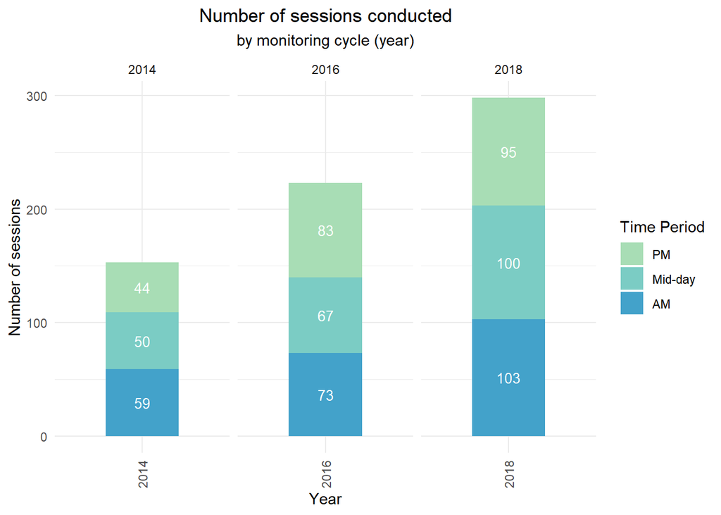

```r
vp_data %>%
  group_by(Year, Period) %>%
  summarise(Sessions = n_distinct(Session, na.rm = TRUE),
            Visitors = n_distinct(ID, na.rm = TRUE)) %>%
  ggplot(., aes(x = factor(Year), y = Sessions, fill = fct_rev(Period))) +
  geom_bar(stat = "identity", width = .5) +
  geom_text(aes(label = Sessions), position = position_stack(vjust = .5), color = "white", size = 3.5) +
  #scale_fill_brewer(type = "seq", palette = "PuBuGn") +
  scale_fill_manual(values = c("#a8ddb5", "#7bccc4", "#43a2ca")) +
  theme_minimal() +
  facet_wrap( ~ factor(Year), scales = "free_x") +
  xlab("Year") +
  ylab("Number of sessions") +
  labs(title = "Number of sessions conducted",
       subtitle = "by monitoring cycle (year)",
       fill = "Time Period") +
  theme(plot.title = element_text(hjust = 0.5),
        plot.subtitle = element_text(hjust = 0.5),
        axis.text.x=element_text(angle=90,hjust=1, vjust = 0.5))
```

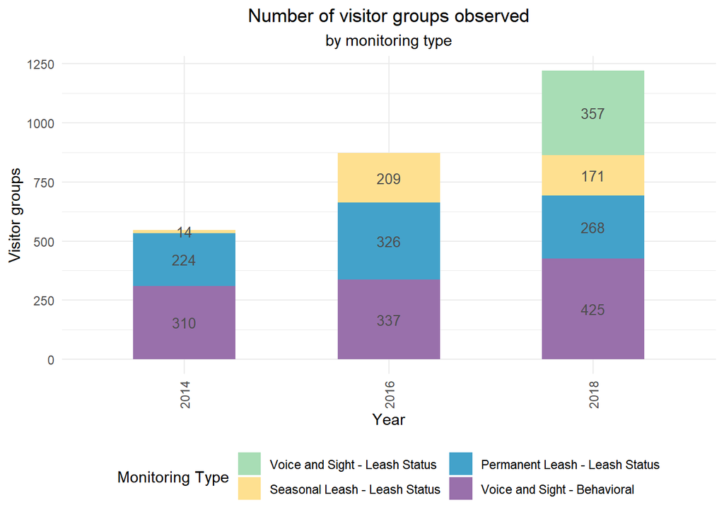

```r
vp_data %>%
  group_by(Year, Type) %>%
  summarise(Sessions = n_distinct(Session),
            Visitors = n_distinct(ID, na.rm = TRUE)) %>%
  ggplot(., aes(x = factor(Year), y = Visitors, fill = fct_rev(Type))) +
  geom_bar(stat = "identity", width = .5) +
  geom_text(aes(label = Visitors), position = position_stack(vjust = .5), color = "grey30", size = 3.5) +
  scale_fill_manual(values = c("#a8ddb5", "#fee090", "#43a2ca", "#9970ab")) +
  theme_minimal() +
  guides(fill = guide_legend(nrow = 2)) +
  xlab("Year") +
  ylab("Visitor groups") +
  labs(title = "Number of visitor groups observed",
       subtitle = "by monitoring type",
       fill = "Monitoring Type") +
  theme(plot.title = element_text(hjust = 0.5),
        plot.subtitle = element_text(hjust = 0.5),
        axis.text.x=element_text(angle=90,hjust=1, vjust = 0.5),
        legend.position = "bottom")
```

```r
vp_data %>%
  group_by(Year, Type) %>%
  summarise()
```

| Year | Type |
| --- | --- |
| 2014 | Voice and Sight - Behavioral |
| 2014 | Permanent Leash - Leash Status |
| 2014 | Seasonal Leash - Leash Status |
| 2016 | Voice and Sight - Behavioral |
| 2016 | Permanent Leash - Leash Status |
| 2016 | Seasonal Leash - Leash Status |
| 2018 | Voice and Sight - Behavioral |
| 2018 | Permanent Leash - Leash Status |
| 2018 | Seasonal Leash - Leash Status |
| 2018 | Voice and Sight - Leash Status |

To see the sample distribution and density of collection types across the entire study period, we can plot `sessionDate` on the x-axis and `start` time on the y-axis.

### Distribution by month

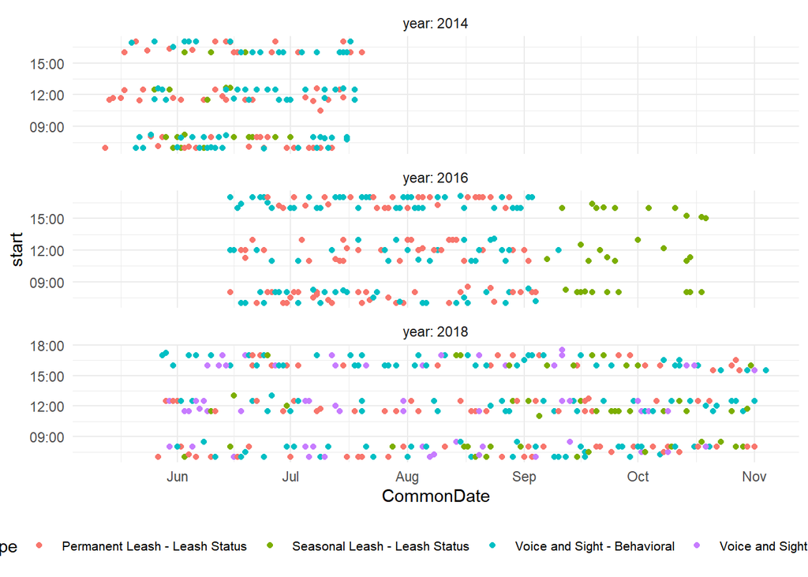

```r
ggplot(sessions_official, aes(x = CommonDate, y = start, group = Type, color = Type)) +
  geom_point() +
  facet_wrap(~ year, nrow = 3, scales = "free_y", labeller = label_both) +
  theme_minimal() +
  theme(
    legend.position = "bottom",
    legend.text = element_text(size = 8)
  )
```

## Visitor Party Composition

Primary Questions

- What are the activity and group size distributions for observed visitor groups?
- What is the distribution of the number of dogs per visitor group?

Distribution of the number of Visitor parties by activity observed for each session type.

```r
# read in visitor party data

vp_data %>%
  filter(No_Observations == 0) %>%
  group_by(Year, Type, Activity) %>%
  summarise(n = n()) %>%
  spread(key = Activity, value = n, fill = 0) %>%
  kable("html", escape = F,
        caption = "Number of visitor parties observed by session type and monitoring year") %>%
  kable_styling("striped", full_width = F, position = "left") %>%
  collapse_rows(columns = 1, valign = "top")
```

Number of visitor parties observed by session type and monitoring year

| Year | Type | Hiker | Runner | Biker | Equestrian | Other |
| --- | --- | --- | --- | --- | --- | --- |
| 2014 | Voice and Sight - Behavioral | 255 | 48 | 6 | 1 | 0 |
|  | Permanent Leash - Leash Status | 190 | 31 | 2 | 1 | 0 |
|  | Seasonal Leash - Leash Status | 9 | 4 | 1 | 0 | 0 |
| 2016 | Voice and Sight - Behavioral | 293 | 40 | 3 | 1 | 0 |
|  | Permanent Leash - Leash Status | 274 | 48 | 2 | 0 | 1 |
|  | Seasonal Leash - Leash Status | 188 | 20 | 1 | 0 | 0 |
| 2018 | Voice and Sight - Behavioral | 355 | 57 | 9 | 3 | 1 |
|  | Permanent Leash - Leash Status | 226 | 41 | 1 | 0 | 0 |
|  | Seasonal Leash - Leash Status | 149 | 20 | 2 | 0 | 0 |
|  | Voice and Sight - Leash Status | 306 | 44 | 4 | 2 | 1 |

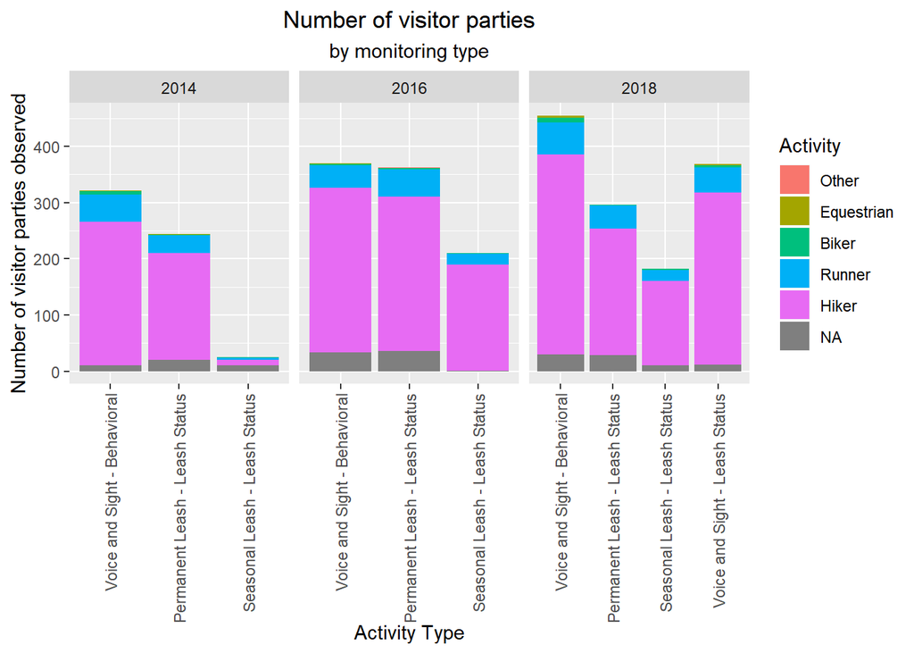

```r
vp_data %>%
  mutate(Activity = factor(Activity, levels = rev(c("Hiker", "Runner", "Biker", "Equestrian", "Other")))) %>%
  ggplot(., aes(Type)) +
  geom_bar(aes(fill = Activity)) +
  #geom_text(stat = 'count', aes(label = ..count..), vjust = -.4, size = 3) +
  facet_wrap(. ~ Year, scales = "free_x") +
  #scale_fill_discrete(name = "Monitoring Type",
  #                    labels = c("Voice & Sight", "Leash Required", "Seasonal Leash")) +
  xlab("Activity Type") +
  ylab("Number of visitor parties observed") +
  labs(title = "Number of visitor parties",
       subtitle = "by monitoring type") +
  theme(plot.title = element_text(hjust = 0.5),
        plot.subtitle = element_text(hjust = 0.5),
        axis.text.x=element_text(angle=90,hjust=1, vjust = 0.5))
```

```r
# vp_data %>%
#   group_by(Year, Type, Activity) %>%
#   summarise(n = n()) %>%
#   kable("html", escape = F,
#         caption = "Number of visitor parties observed by activity type",
#         col.names = c("Year", "Session Type", "Activity", "Visitor Parties")) %>%
#   kable_styling("hover", full_width = F, position = "left")
```

```r
# vp_data %>%
#   filter(sessionType == "Interactions and V&S Control") %>%
#   group_by(visitorID) %>%
#   mutate(numDog_offLeash = sum(numDog_offTag, numDog_offNoTag, numDog_offUnsure)) %>%
#   group_by(year, numDog_offLeash) %>%
#   summarise(number_vp = n(),
#             number_dog = sum(numDog_offLeash),
#             percent = round(number_vp/337*100,1)) %>%
#   kable("html", escape = F,
#         caption = "Number of off-leash dogs by visitor party",
#         col.names = c("Year", "Dogs per Visitor Party", "Visitor Parties", "Dogs", "Percent")) %>%
#   kable_styling("hover", full_width = F, position = "left")
```

```r
# vp_data %>%
#   group_by(Year, Type, All_Dogs) %>%
#   summarise(count_of_groups = n()) %>%
#   # mutate(total_groups = sum(count_of_groups),
#   #        proportion = count_of_groups / total_groups) %>%
#   # ungroup() %>%
#   # mutate(percent = percent(proportion, 1)) %>%
#   # select(-proportion, -total_groups, -count_of_groups) %>%
#   spread(key = All_Dogs, value = count_of_groups, fill = 0) %>%
#   kable("html", escape = F,
#         caption = "Number of visitor groups observed by session type and monitoring year") %>%
#   kable_styling("striped", full_width = F, position = "left") %>%
#   collapse_rows(columns = 1, valign = "top") %>%
#   add_header_above(c(" " = 2, "Dogs in visitor party" = 5)) %>%
#   column_spec(3:7, width = "2cm")
```

```r
vp_data %>%
  filter(No_Observations == 0) %>%
  group_by(Type, Year, All_Dogs) %>%
  summarise(count_of_groups = n()) %>%
  mutate(total_groups = sum(count_of_groups),
         proportion = count_of_groups / total_groups) %>%
  ungroup() %>%
  mutate(percent = percent(proportion, 1)) %>%
  select(-proportion, -count_of_groups, `Sample Size` = total_groups) %>%
  spread(key = All_Dogs, value = percent, fill = 0) %>%
  kable("html", escape = F,
        caption = "Percent of visitor groups observed with") %>%
  kable_styling("striped", full_width = F, position = "left") %>%
  collapse_rows(columns = 1, valign = "top") %>%
  add_header_above(c(" " = 3, "Dogs in visitor party" = 5)) %>%
  column_spec(4:7, width = "2cm")
```

Percent of visitor groups observed with

| Type | Year | Sample Size | Dogs in visitor party 1 | Dogs in visitor party 2 | Dogs in visitor party 3 | Dogs in visitor party 4 | Dogs in visitor party 5 |
| --- | --- | --- | --- | --- | --- | --- | --- |
| Voice and Sight - Behavioral | 2014 | 310 | 72.9% | 21.6% | 4.5% | 1.0% | 0.0% |
|  | 2016 | 337 | 71.5% | 23.7% | 3.9% | 0.6% | 0.3% |
|  | 2018 | 425 | 75.1% | 22.1% | 2.4% | 0.5% | 0.0% |
| Permanent Leash - Leash Status | 2014 | 224 | 79.9% | 17.4% | 2.7% | 0.0% | 0.0% |
|  | 2016 | 325 | 77.8% | 20.6% | 1.5% | 0.0% | 0.0% |
|  | 2018 | 268 | 82.8% | 14.9% | 2.2% | 0.0% | 0.0% |
| Seasonal Leash - Leash Status | 2014 | 14 | 64.3% | 21.4% | 14.3% | 0.0% | 0.0% |
|  | 2016 | 209 | 78.5% | 17.7% | 2.9% | 0.5% | 0.5% |
|  | 2018 | 171 | 81.9% | 14.0% | 3.5% | 0.6% | 0.0% |
| Voice and Sight - Leash Status | 2018 | 357 | 73.9% | 23.8% | 2.2% | 0.0% | 0.0% |

# Compliance Analysis

## Leash and Tag Status

Tag display for all dogs observed in **2018** by trail regulation type, leash and tag status.

```r
source('scripts/vp_data.R')

vp_data %>%
  filter(No_Observations == 0) %>%
  filter(Year == 2018, Type != "Voice and Sight - Behavioral") %>%
  select(Type, Leash_Tag, Leash_No_Tag = Leash_NoTag, Leash_Unsure, Off_Tag, Off_No_Tag = Off_NoTag, Off_Unsure) %>%
  pivot_longer(cols = c(2:7), names_to = "Status", values_to = "Count") %>%
  group_by(Type, Status) %>%
  summarise(Count = sum(Count)) %>%
  mutate(Frequency = Count/sum(Count),
         Leash = c(rep("On Leash", 3), rep("Off Leash", 3)),
         Status = gsub("_", " ", Status),
         Tag = substr(Status, if_else(grepl("Leash", Status), 7, 5), nchar(Status))) %>%
  select(-Count, -Status) %>%
  ungroup() %>%
  mutate(Frequency = percent(Frequency, 1)) %>%
  pivot_wider(names_from = Type, values_from = Frequency) %>%
  kable("html", escape = F,
        caption = "",
        col.names = c("Status", "Tag", "Permanent", "Seasonal", "Voice and Sight")) %>%
  collapse_rows(columns = 1, valign = "top") %>%
  kable_styling("striped", full_width = F, position = "left")
```

| Status | Tag | Permanent | Seasonal | Voice and Sight |
| --- | --- | --- | --- | --- |
| On Leash | No Tag | 37.2% | 18.6% | 20.1% |
|  | Tag | 38.1% | 36.7% | 16.6% |
|  | Unsure | 6.2% | 2.9% | 2.4% |
| Off Leash | No Tag | 5.0% | 7.6% | 5.9% |
|  | Tag | 12.2% | 30.5% | 50.0% |
|  | Unsure | 1.2% | 3.8% | 5.0% |

Visitor party compliance with leash and tag regulations

```r
vp_data %>%
  filter(No_Observations == 0) %>%
  select(Year, Type, Compliance = Leash_Tag_Compliance) %>%
  group_by(Year, Type, Compliance) %>%
  summarise(Count = n()) %>%
  mutate(Frequency = Count/sum(Count)) %>%
  ungroup() %>%
  mutate(Frequency = percent(Frequency, 1)) %>%
  select(Type, Year, Compliance, Frequency) %>%
  arrange(Type, Year) %>%
  pivot_wider(names_from = Compliance, values_from = Frequency) %>%
  kable("html", escape = F,
        caption = "") %>%
  kable_styling("striped", full_width = F, position = "left")  %>%
  collapse_rows(columns = 1, valign = "top")
```

| Type | Year | Compliant | Non-Compliant | Unsure |
| --- | --- | --- | --- | --- |
| Voice and Sight - Behavioral | 2014 | 69.4% | 20.0% | 10.6% |
|  | 2016 | 56.4% | 19.9% | 23.7% |
|  | 2018 | 81.9% | 12.5% | 5.6% |
| Permanent Leash - Leash Status | 2014 | 83.5% | 16.5% | NA |
|  | 2016 | 76.3% | 23.7% | NA |
|  | 2018 | 79.9% | 20.1% | NA |
| Seasonal Leash - Leash Status | 2014 | 57.1% | 42.9% | NA |
|  | 2016 | 62.2% | 37.8% | NA |
|  | 2018 | 56.1% | 43.9% | NA |
| Voice and Sight - Leash Status | 2018 | 88.8% | 6.4% | 4.8% |

```r
# case_when(Type == "Voice and Sight - Behavioral" & Off_Unsure >= 1  ~ "Unsure",
#                                 Type == "Voice and Sight - Behavioral" & Off_NoTag >= 1   ~ "Non-Compliant",
#                                 Type == "Permanent Leash - Leash Status" & Off_Leash >= 1 ~ "Non-Compliant",
#                                 TRUE ~ "Compliant"))
```

## Voice and Sight - Behavioral Monitoring

What is the frequency and compliance with pickup and removal of excrement? What is the frequency of visitor parties having more than 2 off-leash dogs per adult guardian?

```r
vs_visitor <- vp_data %>%
  filter(Type == "Voice and Sight - Behavioral")
```

### Tag display

```r
tag_table <- table(vs_visitor$Leash_Tag_Compliance, vs_visitor$Year)

round(prop.table(tag_table, 2)*100,1) %>%
  kable("html", escape = F) %>%
  kable_styling("striped", full_width = F, position = "left")
```

|  | 2014 | 2016 | 2018 |
| --- | --- | --- | --- |
| Compliant | 69.4 | 56.4 | 81.9 |
| Non-Compliant | 20.0 | 19.9 | 12.5 |
| Unsure | 10.6 | 23.7 | 5.6 |

```r
#chisq.test(tag_table)
```

### Dog ratios

```r
twodog_table <- table(vs_visitor$Dog_Ratio_Compliance, vs_visitor$Year)
twodog_table %>%
  kable("html", escape = F) %>%
  kable_styling("striped", full_width = F, position = "left")
```

|  | 2014 | 2016 | 2018 |
| --- | --- | --- | --- |
| Compliant | 8 | 7 | 6 |
| Non-Compliant | 6 | 3 | 4 |
| Only 2 dogs in group | 296 | 327 | 415 |

```r
#chisq.test(twodog_table)
```

### Excrement Pickup

```r
excrement_table <- table(vs_visitor$Excrement_Compliance, vs_visitor$Year, useNA = "no")
excrement_table %>%
  kable("html", escape = F) %>%
  kable_styling("striped", full_width = F, position = "left")
```

|  | 2014 | 2016 | 2018 |
| --- | --- | --- | --- |
| Compliant | 18 | 11 | 22 |
| Non-Compliant | 8 | 8 | 6 |
| No poop events | 284 | 318 | 397 |

```r
#chisq.test(excrement_table)
```

#Supplamental Tables

## Sessions and Visitor Parties

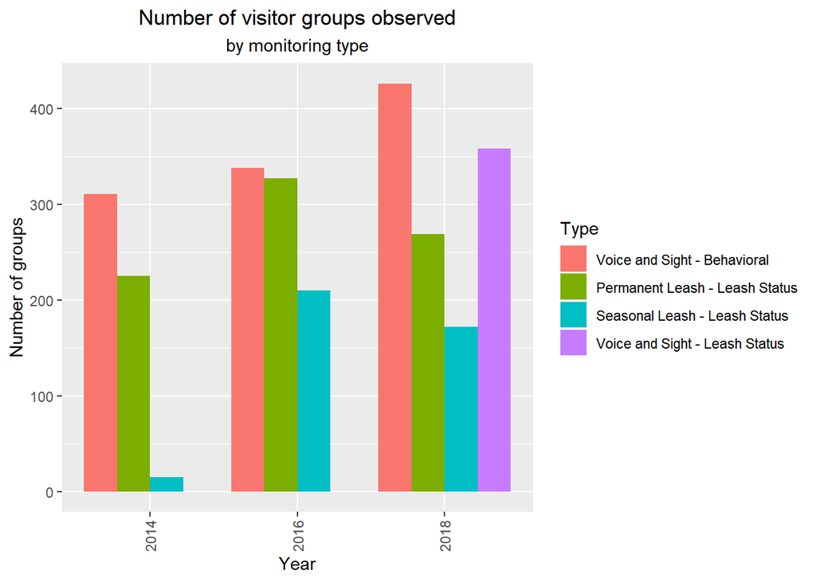

```r
vp_data %>%
  group_by(Year, Type) %>%
  summarise(sessions = n_distinct(Session),
            visitors = n_distinct(ID)) %>%
  ggplot(., aes(factor(Year), visitors)) +
  geom_bar(aes(fill = Type), stat = "identity", position = position_dodge(preserve = "single")) +
  #geom_text(stat = 'count', aes(label = ..count..), vjust = -.4, size = 3) +
  #facet_wrap(. ~ Year, scales = "free_x") +
  #scale_fill_discrete(name = "Monitoring Type",
  #labels = c("Voice & Sight", "Leash Required", "Seasonal Leash")) +
  xlab("Year") +
  ylab("Number of groups") +
  labs(title = "Number of visitor groups observed",
       subtitle = "by monitoring type") +
  theme(plot.title = element_text(hjust = 0.5),
        plot.subtitle = element_text(hjust = 0.5),
        axis.text.x=element_text(angle=90,hjust=1, vjust = 0.5))
```

```r
vp_data %>%
  group_by(Regulation, Monitoring, Site, Year) %>%
  summarise(Sessions = n_distinct(Session),
            Visitors = n_distinct(ID)) %>%
  pivot_longer(cols = 5:6, names_to = "name", values_to = "count") %>%
  pivot_wider(names_from = c(Year, name), values_from = count, values_fill = list(count = 0)) %>%
  kable(format = "html", caption = "Number of visitor parties observed for eash session",
        col.names = c("Trail Regulation", "Monitoring Type", "Site", rep(c("Sessions", "Groups"),3))) %>%
  #collapse_rows(columns = 1, valign = "top") %>%
  add_header_above(c(" " = 3, "2014" = 2, "2016" = 2, "2018" = 2)) %>%
  kable_styling(c("hover", "condensed")) %>%
  scroll_box(height = "700px")
```

Number of visitor parties observed for eash session

| Trail Regulation | Monitoring Type | Site | 2014 Sessions | 2014 Groups | 2016 Sessions | 2016 Groups | 2018 Sessions | 2018 Groups |
| --- | --- | --- | --- | --- | --- | --- | --- | --- |
| Permanent Leash | Leash Status | Baseline/Bluebell-Baird | 1 | 10 | 0 | 0 | 0 | 0 |
| Permanent Leash | Leash Status | Bear Peak West Ridge/Bear Canyon | 5 | 13 | 4 | 4 | 0 | 0 |
| Permanent Leash | Leash Status | Boulder Creek Path - Foothills | 3 | 11 | 3 | 15 | 3 | 9 |
| Permanent Leash | Leash Status | Buckingham Park | 5 | 5 | 2 | 5 | 6 | 8 |
| Permanent Leash | Leash Status | Chapman Trail | 3 | 3 | 0 | 0 | 0 | 0 |
| Permanent Leash | Leash Status | Cherryvale TH | 3 | 5 | 4 | 1 | 0 | 0 |
| Permanent Leash | Leash Status | Cottontail Trail | 3 | 12 | 1 | 7 | 0 | 0 |
| Permanent Leash | Leash Status | Cottonwood TH | 3 | 15 | 4 | 21 | 0 | 0 |
| Permanent Leash | Leash Status | Cowdrey Draw | 1 | 1 | 2 | 2 | 4 | 3 |
| Permanent Leash | Leash Status | Dakota Ridge Trail | 4 | 35 | 4 | 47 | 3 | 42 |
| Permanent Leash | Leash Status | Doudy Draw TH | 1 | 2 | 0 | 0 | 0 | 0 |
| Permanent Leash | Leash Status | E.M. Greenman | 0 | 0 | 1 | 3 | 1 | 1 |
| Permanent Leash | Leash Status | East Boulder - Teller Lake ADA | 5 | 7 | 5 | 4 | 1 | 2 |
| Permanent Leash | Leash Status | Eldorado Canyon Trail | 4 | 2 | 1 | 1 | 2 | 1 |
| Permanent Leash | Leash Status | Foothills South/Old Kiln | 2 | 23 | 1 | 14 | 4 | 19 |
| Permanent Leash | Leash Status | Fowler Trail | 3 | 11 | 2 | 6 | 3 | 4 |
| Permanent Leash | Leash Status | Green Mountain West Ridge/Green Bear | 1 | 1 | 6 | 10 | 1 | 2 |
| Permanent Leash | Leash Status | High Plains Trail | 4 | 4 | 1 | 1 | 5 | 2 |
| Permanent Leash | Leash Status | Homestead Leash Trail | 0 | 0 | 5 | 35 | 0 | 0 |
| Permanent Leash | Leash Status | KOA Lake Greenway | 0 | 0 | 3 | 1 | 2 | 2 |
| Permanent Leash | Leash Status | Lefthand Trail | 1 | 1 | 3 | 2 | 1 | 2 |
| Permanent Leash | Leash Status | Lefthand Trailhead | 6 | 7 | 2 | 1 | 3 | 1 |
| Permanent Leash | Leash Status | Lost Gulch Trail | 4 | 4 | 8 | 18 | 2 | 6 |
| Permanent Leash | Leash Status | Lower Big Bluestem/Bluestem Connector | 0 | 0 | 6 | 17 | 3 | 8 |
| Permanent Leash | Leash Status | Marshall Lake Lookout | 0 | 0 | 2 | 2 | 1 | 4 |
| Permanent Leash | Leash Status | Old Kiln Trail | 0 | 0 | 2 | 6 | 2 | 2 |
| Permanent Leash | Leash Status | Old Mesa Trail | 2 | 1 | 4 | 1 | 0 | 0 |
| Permanent Leash | Leash Status | Post Office Access | 5 | 2 | 0 | 0 | 2 | 2 |
| Permanent Leash | Leash Status | Sage TH | 1 | 4 | 0 | 0 | 0 | 0 |
| Permanent Leash | Leash Status | South Boulder Creek Greenway | 1 | 6 | 2 | 1 | 3 | 17 |

[output cut: 134 more lines]

[^1]: *Naturalistic* is a research method commonly used by psychologists and other social scientists which involves observing subjects in their natural environment. In the case of this study, it means observing people on OSMP lands in the context in which they normally recreate/visit.
[^2]: *Visitor party* refers to a combination of people and dogs who appear to be traveling together as an intentional group